# Report statistico sul dataset **Valorant**

Università degli Studi di Bergamo | Ingegneria Informatica | Corso di Statistica

Gruppo: Tianwen **Berardi Francesco** (n. 1099783) **Meoli Richard** (n. 1099274) **Noris Francesco** (n. 1100339) **Pullano Gabriele** (n. 1099559)

Dicembre 2025 - Gennaio 2026

## 1 **Obiettivo dell’analisi**

In un ecosistema tattico complesso come quello di *Valorant*, il successo di un team può essere ricondotto a due “*filosofie*” contrapposte: la capacità di un singolo fuoriclasse di “trascinare” i compagni (il cosiddetto *carry*) o la solidità di un collettivo ben coordinato. Il presente studio si propone di indagare i determinanti della vittoria nel contesto del *Valorant Champions Tour 2024*, cercando di quantificare statisticamente il peso di queste due dimensioni. Attraverso l’applicazione di un modello di **regressione logistica**, l’analisi mira a rispondere alla seguente domanda: la probabilità di successo è predetta meglio dal **talento individuale** dei singoli giocatori o da metriche che riflettono la **coesione e il supporto reciproco** all’interno del team?

## 2 **Preparazione dei dati**

### 2.1 *Presentazione del dataset*

Il dataset oggetto dello studio raccoglie le statistiche dettagliate dei match del *Valorant Champions Tour 2024*. Nella sua forma grezza, si presenta con un’estensione considerevole: comprende **36.310 osservazioni** distribuite su **39 variabili**. Queste ultime documentano molteplici aspetti delle competizioni: dai metadati del torneo alle informazioni su team e giocatori, fino a specifici indicatori di performance tecnica. Tale mole di dati costituisce la base di partenza per la successiva fase di selezione e aggregazione, volta a isolare i fattori determinanti per il successo dei team.

### 2.3 *Filtro delle osservazioni*

Al fine di rimuovere le ridondanze strutturali, il dataset è stato filtrato secondo due criteri:

- **Fase di gioco (`Side`):** il dataset originale registra separatamente le statistiche per le fasi di attacco e difesa. Si è scelto di isolare unicamente la modalità **“both”**, che offre una panoramica della performance dell’intero match, evitando di frammentare i dati per lo stesso evento.
- **Modalità di uccisione (`Kill.Type`):** sono state rimosse le osservazioni relative a tipologie di eventi parziali (es. *First Kills*), mantenendo esclusivamente la categoria **“All Kills”**. Ciò garantisce che gli indici di performance (come il *Rating*) siano calcolati sulla totalità delle azioni di gioco, eliminando duplicati informativi e garantendo omogeneità nelle metriche di performance.

A seguito di questa selezione, il dataset analizzato si riduce a un totale di **7.419 osservazioni**.

### 2.4 *Scrematura delle variabili*

Dopo aver applicato i filtri sulle osservazioni, si è proceduto alla selezione delle variabili ritenute utili in funzione dell’obiettivo dell’analisi. La seguente tabella illustra le scelte effettuate.

[output not shown]

Subito dopo la selezione è stata generata la variabile risposta binaria **`Win`**, pilastro centrale dell’analisi. Tale variabile, ottenuta confrontando i punteggi `Team.A.Score` e `Team.B.Score`, assume valore **1** qualora il team di riferimento abbia totalizzato un punteggio superiore a quello avversario. In conclusione, il processo ha consentito di ricondurre il dataset a un totale di **17 variabili**.

### 2.5 *Aggregazione dei dati per Team*

L’operazione conclusiva della fase di preparazione consiste nella transizione dell’unità statistica dal “singolo giocatore” alla “**squadra**”, al fine di allineare i dati all’obiettivo di ricerca. La ristrutturazione è stata articolata in 4 passaggi.

1. **Risoluzione della ridondanza dei duelli**: il dataset originale registra la performance di ogni giocatore in relazione a ciascuno dei cinque avversari, quintuplicando di fatto le osservazioni. Attraverso l’operazione di `distinct()`, sono stati isolati i record univoci per ogni giocatore in ogni scontro, garantendo che gli indici globali di partita non venissero erroneamente moltiplicati in fase di calcolo.
2. **Trattamento delle stringhe**: alcune variabili come `Kill..Assist..Trade..Survive..` e `Headshot..` erano originariamente codificate come stringhe di testo contenenti il simbolo di percentuale (‘%’). Si è proceduto alla rimozione sintattica di tale simbolo e alla successiva conversione in valori numerici decimali, al fine di consentire il calcolo delle medie di squadra ed evitare la generazione di errori.
3. **Definizione delle chiavi di aggregazione**: le osservazioni sono state raggruppate in base alle variabili `Match.Name` e `Map`. L’inclusione della mappa come chiave tecnica, sebbene non oggetto di studio diretto, è stata indispensabile per trattare ogni singola sfida come un’osservazione indipendente. Questa scelta ha permesso di evitare il collasso di interi match (spesso composti da più mappe) in un’unica riga.
4. **Differenziazione tra medie e somme**: la sintesi delle performance è stata guidata dalla natura delle variabili. Per gli indici qualitativi (`KAST_mean`, `HS_mean`, `Rating_Mean`, `ACS_Mean`, `ADR_Mean`) è stata adottata la **media di squadra** per rappresentare il livello medio del collettivo. Per i volumi di gioco (`Kills_Tot`, `Deaths_Tot`, `Assists_Tot`, `FirstKills_Tot`,`FirstDeaths_Tot`), si è optato per la **somma totale**, così da catturare l’output complessivo prodotto dal team durante il match.

Il risultato di questo processo è un dataset in cui ogni riga rappresenta univocamente la performance di una **squadra** in una determinata mappa, corredata dalla variabile risposta binaria `Win` derivata in precedenza. Si è infine proceduto alla rimozione delle variabili `Team.A.Score`, `Team.B.Score` e `Player`, divenute superflue. Il dataset consta ora di **260 osservazioni** e **14 variabili**.

## 3 **Exploratory Data Analysis**

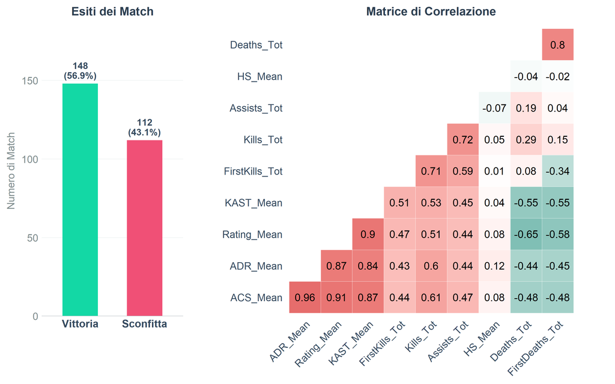

Il *grafico a barre* (sinistra) illustra la ripartizione degli esiti per il campione di 260 osservazioni, registrando **148** vittorie e **112** sconfitte (*56.9 % - 43.1 %*). Sebbene si riscontri una lieve **asimmetria** nella distribuzione, le due classi risultano rappresentate in modo sufficientemente equilibrato. Tale bilanciamento assicura che il futuro modello di **regressione logistica** possa apprendere efficacemente le caratteristiche di entrambi i gruppi, evitando il rischio di distorsioni sistematiche verso la classe maggioritaria.

L’analisi della *matrice di correlazione* (destra) evidenzia una marcata ridondanza informativa tra i principali indicatori di performance offensiva (**multicollinearità**). Si osserva una correlazione quasi perfetta tra `ADR_Mean` e `ACS_Mean` (**0.96**), e valori estremamente elevati tra questi e il `Rating_Mean`. Tali evidenze suggeriscono che queste variabili catturino la medesima dimensione del successo, prefigurando potenziali problemi di multicollinearità per il modello di regressione. Al contrario, la variabile relativa alla precisione (`HS_mean`) risulta quasi totalmente decorrelata dagli altri predittori, indicando che l’efficienza meccanica nel “*colpo alla testa*” non si traduce linearmente in volumi di danno o rating superiori.

## 4 **Data Engineering**

### 4.1 *Creazione di nuovi indicatori*

Per rispondere al quesito di ricerca e superare i limiti descrittivi delle semplici medie di squadra, sono stati ingegnerizzati quattro nuovi indicatori. Queste metriche mirano a catturare dimensioni della performance che altrimenti resterebbero latenti, offrendo una prospettiva più profonda sulla distribuzione del talento e sulla sinergia tattica.

- **Rating Massimo (`Rating_Max`)**: rappresenta il valore di *Rating* più elevato all’interno del team. L’obiettivo è quantificare il peso del picco prestazionale individuale (il cosiddetto “fuoriclasse”) nel determinare l’esito della partita.
- **Disparità di Rating (`Rating_SD`)**: calcola la deviazione standard dei *Rating* dei cinque componenti della squadra. Questo indice misura la disparità interna: un valore elevato indica una squadra sbilanciata con forte divario tra i membri, mentre un valore basso suggerisce un contributo equilibrato di tutto il collettivo.
- **Concentrazione di Kill (`Kill_Concentration`)**: definito come il rapporto tra le uccisioni del miglior marcatore e il totale delle uccisioni di squadra. Questo parametro permette di valutare quanto il peso offensivo del team sia delegato a un unico trascinatore rispetto a una distribuzione più omogenea delle eliminazioni.
- **Rapporto Assist / Kill (`Assists_per_Kill`)**: rapporto tra il numero totale di assist e quello delle uccisioni di squadra. Funge da termometro della coordinazione tattica, indicando in che misura le eliminazioni siano frutto di un lavoro preparatorio collettivo piuttosto che di iniziative isolate.

Con queste aggiunte, il dataset è ora caratterizzato da **260 osservazioni** e **18 variabili**.

### 4.2 *Analisi visiva degli indicatori*

Al fine di analizzare l’utilità degli indici creati in relazione alla loro capacità di distinguere i due gruppi di interesse, si riportano di seguito i relativi *boxplot* comparativi.

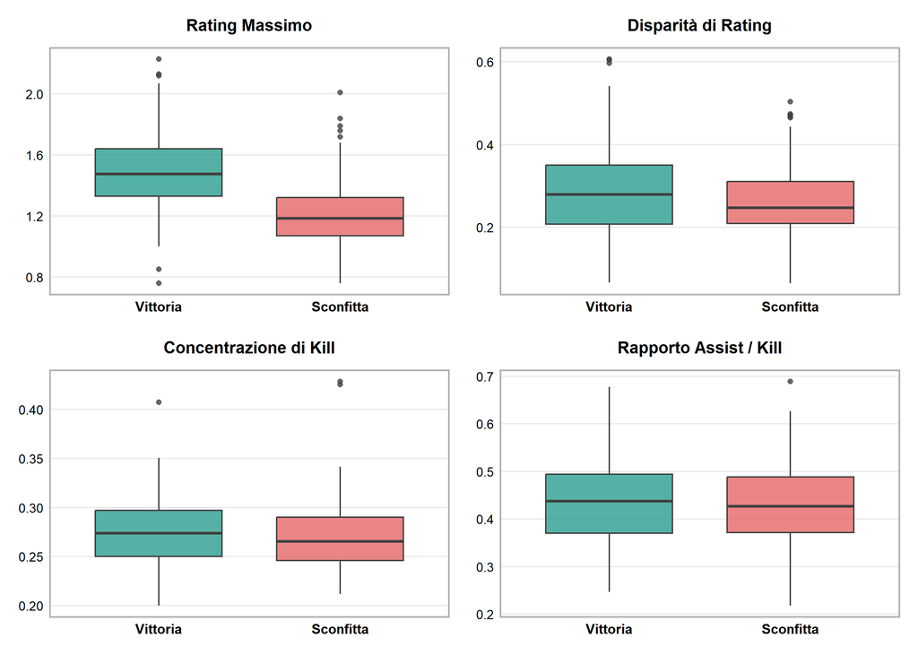

L’analisi visiva evidenzia le seguenti dinamiche rispetto all’esito del match.

- **Impatto del talento di punta** (`Rating_Max`): è l’unico indicatore a mostrare una separazione netta. I vincitori presentano una mediana superiore (~1.5 vs ~1.2) e scarsa sovrapposizione, delineando il picco prestazionale individuale come il *driver* visivamente più solido per il successo.
- **Coesione come requisito** (`Rating_SD` e `Assists_per_Kill`): le distribuzioni quasi sovrapponibili suggeriscono che l’equilibrio interno e la sinergia siano requisiti minimi comuni a tutti i team d’élite, ma non fattori discriminanti per la vittoria.
- **Limite della polarizzazione** (`Kill_Concentration`): la mancata separazione tra i gruppi indica che accentrare le *kill* su un singolo è meno efficace dell’impatto globale (Rating): il “volume” di fuoco conta meno della qualità generale della giocata.
- **Analisi delle anomalie**: la presenza di *outlier* rivela scenari di “carry impotente” (ottime performance singole in sconfitta) o vittorie ottenute nonostante forti squilibri interni, confermando la natura non lineare della competizione.

In conclusione, sebbene il **talento di punta** appaia determinante, l’attuale analisi bivariata non coglie le interazioni simultanee; il peso marginale reale di ogni fattore sarà quindi isolato attraverso il successivo modello di regressione **multivariata**.

## 5 **Variable Selection**

L’obiettivo di questa fase è quello di selezionare i predittori che massimizzano la **capacità esplicativa** del modello, minimizzando al contempo il rumore statistico.

### 5.1 *Data splitting*

Prima di avviare la selezione delle variabili, il dataset è stato depurato dai metadati descrittivi (`Match.Name`, `Map`, `Player.Team`) che, pur contestualizzando l’evento, non possiedono valore predittivo statistico. Successivamente, si è proceduto alla suddivisione casuale delle osservazioni in **2 partizioni**:

1. **Training Set (75%):** utilizzato per tutte le fasi di addestramento e selezione delle variabili (*VIF*, *Stepwise*, *LASSO/RIDGE*, *Cross Validation*).
2. **Test Set (25%):** mantenuto rigorosamente isolato fino alla fine dell’analisi per testare la capacità di generalizzazione del modello su dati inediti.

Questa separazione è fondamentale per garantire l’onestà della valutazione finale e scongiurare il rischio di *data leakage*, fenomeno che si verifica quando informazioni che dovrebbero essere “nascoste” vengono impropriamente utilizzate durante l’addestramento, portando a stime delle prestazioni irrealisticamente ottimistiche.

### 5.2 *Analisi di multicollinearità - VIF*

Per scongiurare il rischio di **multicollinearità** — ovvero una situazione di dipendenza lineare tra i predittori che renderebbe instabili le stime dei coefficienti — si è fatto ricorso al *Variance Inflation Factor* (VIF).

Il VIF per una variabile $j$ è definito come:

$$VIF_j = \frac{1}{1 - R^2_j}$$

dove $R^2_j$ è il coefficiente di determinazione ottenuto regredendo la variabile $X_j$ su tutte le altre variabili esplicative. Un valore di $VIF > 5$ indica che la variabile porta con sé un’informazione già ampiamente spiegata dagli altri predittori.

L’analisi è stata condotta con un approccio **iterativo** applicato al *Training Set*. Partendo dal modello ottenuto al punto precedente, si sono calcolati i VIF ad ogni passaggio, eliminando progressivamente la variabile con il valore più elevato fino al raggiungimento della soglia di sicurezza ($VIF < 5$ per tutti i predittori), tenendo anche conto dei risultati ottenuti tramite la *matrice di correlazione* nella fase di *EDA*. Di seguito si riportano le esclusioni effettuate.

- **Iterazione 1**: Rimossa variabile **`Kills_Tot`**.
  - **VIF:** 72.22 (distacco dal secondo: +18.43)
  - **Interpretazione:** Alta collinearità generica con il resto dei predittori.
- **Iterazione 2**: Rimossa variabile **`Assists_Tot`**.
  - **VIF:** 36.8 (distacco dal secondo: +7.42)
  - **Interpretazione:** Alta collinearità generica con il resto dei predittori.
- **Iterazione 3**: Rimossa variabile **`ACS_Mean`**.
  - **VIF:** 23.58 (distacco dal secondo: +0.83)
  - **Interpretazione:** Correlazione quasi perfetta (0.96) con ADR_Mean.
- **Iterazione 4**: Rimossa variabile **`Rating_Mean`**.
  - **VIF:** 20.56 (distacco dal secondo: +7.9)
  - **Interpretazione:** Correlazione molto elevata (0.87) con ADR_Mean.
- **Iterazione 5**: Rimossa variabile **`Deaths_Tot`**.
  - **VIF:** 7.93 (distacco dal secondo: +0.8)
  - **Interpretazione:** VIF maggiore, inoltre è una metrica poco informativa rispetto agli altri indicatori.

Al termine del processo, si è giunti ad un set di **9 variabili** esplicative (oltre alla variabile risposta `Win`), riportate nella tabella sottostante.

Tabella finale Variabile-VIF

| Variabile | VIF | Variabile | VIF | Variabile | VIF |
| --- | --- | --- | --- | --- | --- |
| Rating_Max | 4.79 | Rating_SD | 2.98 | FirstDeaths_Tot | 1.22 |
| KAST_Mean | 4.09 | Kill_Concentration | 2.03 | Assists_per_Kill | 1.15 |
| ADR_Mean | 4.05 | FirstKills_Tot | 1.63 | HS_Mean | 1.10 |

### 5.3 *Approccio classico: Stepwise Selection*

Per isolare i predittori più efficaci, si è adottata la procedura **Stepwise**, utilizzando l’**AIC** (*Akaike Information Criterion*) come metrica di giudizio. L’**AIC** funge da “bilancia statistica”: premia la capacità del modello di adattarsi ai dati, ma aggiunge una penalizzazione per ogni variabile aggiunta. Attraverso questo meccanismo, il criterio permette di ottimizzare il *variance-bias trade-off*, selezionando modelli che riducono al minimo l’errore di stima (bias) senza cadere nella trappola dell’overfitting (alta varianza).

L’algoritmo è stato applicato al dataset post-VIF confrontando tre strategie di esplorazione.

1. **Forward Selection**: parte da un modello vuoto e aggiunge una variabile alla volta.
2. **Backward Elimination**: parte dal modello completo e scarta progressivamente le variabili ritenute inutili.
3. **Bidirezionale (Both)**: è la tecnica più flessibile, ad ogni passaggio valuta sia l’aggiunta di nuove variabili che la rimozione di quelle divenute ridondanti a seguito dei nuovi inserimenti, permettendo così al modello di correggere le scelte precedenti.

Confronto performance algoritmi

| Metodo | AIC | N. Variabili |
| --- | --- | --- |
| Forward Selection | 217.7284 | 3 |
| Backward Elimination | 217.7284 | 3 |
| Bidirezionale (Both) | 217.7284 | 3 |

Variabili selezionate

| Variabile | Coefficienti | P-value |
| --- | --- | --- |
| Rating_Max | 4.824 | 0.0000014 |
| Rating_SD | -4.552 | 0.0341093 |
| FirstDeaths_Tot | -0.116 | 0.0688837 |

L’analisi conferma la robustezza del set di variabili identificato ($AIC \approx 217.7$, identico per *backward*, *forward* e *both*), evidenziando tre driver chiave:

1. `Rating_Max` (coefficiente positivo): il talento del miglior giocatore aumenta drasticamente la probabilità di vittoria (p-value bassissimo).
2. `Rating_SD` (coefficiente negativo): lo squilibrio interno penalizza la squadra (serve coesione nei livelli di skill).
3. `FirstDeaths_Tot` (coefficiente negativo): la tendenza a subire la prima eliminazione riduce le chance di successo.

### 5.4 *Approccio moderno: LASSO/RIDGE*

A completamento della fase di selezione, si è applicato un approccio basato sulla **regolarizzazione**, una tecnica che migliora la capacità di generalizzazione del modello penalizzando le stime dei coefficienti per ridurre il rischio di *overfitting*.  
Sono stati confrontati due metodi distinti:

- **LASSO**: applicando una penalità rigorosa, questo algoritmo ha la proprietà di azzerare completamente i coefficienti delle variabili meno rilevanti.
- **Ridge**: A differenza della LASSO, questo metodo contrae i coefficienti verso lo zero senza mai annullarli. È particolarmente efficace nel gestire gruppi di variabili correlate, distribuendo il peso predittivo tra di esse invece di escluderle.

Per entrambi, l’intensità della penalità ottimale è stata calibrata tramite *10-Fold Cross-Validation*. I coefficienti stimati dai modelli così ottimizzati sono riportati nella tabella di confronto sottostante.

Analisi dei coefficienti

| Metodo | Kill_Concentration | KAST_Mean | Rating_Max | HS_Mean | Assists_per_Kill | FirstDeaths_Tot | Rating_SD | FirstKills_Tot | ADR_Mean |
| --- | --- | --- | --- | --- | --- | --- | --- | --- | --- |
| LASSO | 0.00 | 2.734 | 2.492 | 0.000 | 0.000 | -0.079 | 0.000 | 0.00 | 0.000 |
| Ridge | 3.21 | 2.923 | 1.295 | -0.742 | -0.485 | -0.078 | -0.064 | 0.02 | 0.011 |

L’analisi congiunta dei metodi classici e regolarizzati permette di definire i tre set di variabili che verranno sottoposti a validazione comparativa. Per quanto riguarda la *Ridge*, non operando un azzeramento automatico dei coefficienti, si sono selezionati i 3 predittori con il valore assoluto più elevato.

I tre set di variabili candidati risultanti sono:  
1. **Set Stepwise**: `Rating_Max`, `Rating_SD`, `FirstDeaths_Tot`.  
2. **Set LASSO**: `Rating_Max`, `KAST_Mean`, `FirstDeaths_Tot`.  
3. **Set Ridge**: `Kill_Concentration`, `KAST_Mean`, `Rating_Max`.

## 6 **Model Selection**

In questa sezione si procede alla valutazione comparativa dei set di variabili candidati e al successivo raffinamento (*refinement*) del modello vincitore tramite analisi delle interazioni e diagnostica.

### 6.1 *Confronto tra modelli (10-Fold Cross Validation)*

Per selezionare il modello più performante tra le tre configurazioni candidate, si è proceduto ad una stima delle capacità predittive tramite **10-Fold Cross-Validation**. Questa tecnica consiste nel suddividere casualmente il campione in 10 gruppi (*folds*): iterativamente, il modello viene addestrato su 9 gruppi e testato sul decimo rimanente. Il processo restituisce l’**Errore Medio di Previsione** commesso nelle iterazioni, da cui si deriva l’**Accuratezza Stimata** ($1 - \text{errore}$) per quantificare la percentuale di successi attesa.

È cruciale precisare che questa procedura è stata applicata **esclusivamente** al *Training Set*. Sebbene le stime risultanti possano essere lievemente ottimistiche (*bias* di selezione), essendo che le variabili sono state identificate su questi stessi dati, tale approccio è metodologicamente necessario: utilizzare il *Test Set* in questa fase di confronto costituirebbe un *data leakage*, invalidando la sua funzione. Accettiamo quindi questo lieve *bias* in fase di selezione pur di garantire che il *Test Set* rimanga un banco di prova totalmente “nuovo” per la valutazione del modello finale.

I tre set di variabili sono stati utilizzati per addestrare modelli di **regressione logistica standard**, ottenendo i seguenti risultati:

Confronto tra modelli (10-Fold CV)

| Modello | Errore CV | Accuratezza |
| --- | --- | --- |
| Stepwise Set | 0.2564 | 74.36% |
| LASSO Set | 0.2821 | 71.79% |
| Ridge Set | 0.2667 | 73.33% |

Il confronto decreta il modello derivato dal set *Stepwise* come migliore, con un’accuratezza stimata del **74.36%**, risultato che offre alcune interessanti chiavi di lettura.

- **Equilibrio vs Consistenza (vs *LASSO*):** Il set *Stepwise*, che include la deviazione standard del rating (`Rating_SD`), supera il set *LASSO* basato sul `KAST`. Ciò suggerisce che, per vincere, non è sufficiente che i giocatori siano “mediamente utili” (`KAST`), ma è cruciale che il divario di abilità tra il “*carry*” e il resto del team sia contenuto.
- **Equilibrio vs Aggressività (vs *Ridge*):** *Stepwise* supera anche il set *Ridge*, che scommetteva sulla variabile `Kill_Concentration`. Questo dato ridimensiona il valore della pura potenza di fuoco accentrata: avere un singolo giocatore che ottiene la maggior parte delle eliminazioni non garantisce la vittoria quanto il mantenere un livello di abilità omogeneo all’interno della squadra.

Sulla base di queste evidenze, il set *Stepwise* (`Rating_Max` + `Rating_SD` + `FirstDeaths_Tot`) viene selezionato come modello definitivo per le successive fasi di raffinamento e diagnostica.

### 6.2 *Rifinitura del modello*

Definito il set di variabili ottimale si è proceduto a un’ultima verifica strutturale per indagare la presenza di effetti d’**interazione**. Nello specifico, è stata testata l’ipotesi di **interazione tra talento ed equilibrio** (`Rating_Max` * `Rating_SD`): l’obiettivo è verificare se l’efficacia del “*fuoriclasse*” nel determinare la vittoria vari a seconda di quanto il resto della squadra è sbilanciato, o se i due fattori agiscano in modo indipendente. Per validare questa ipotesi, è stato effettuato un confronto tra il modello base (detto “*annidato*”) e il modello con termine di interazione. La verifica si è basata su un **Likelihood Ratio Test** (*test del rapporto di verosimiglianza*), applicato mediante analisi della devianza (`anova`). Tale test valuta se la riduzione dell’errore (devianza) ottenuta grazie all’interazione sia sufficientemente ampia da giustificare la maggiore complessità del modello, o se sia attribuibile al caso.

Il test ha restituito un *p-value* di 0.74. Poiché tale valore è superiore al livello di significatività *0.05*, si conclude che l’**interazione non è significativa**. Si sceglie pertanto di procedere con il modello base.

Di seguito si riportano le stime finali degli *Odds Ratio* e dei relativi *p-values*, calcolati sull’intero *Training Set*.

Tabella degli Odds-Ratio

| Variabile | Odds Ratio | P-Value |
| --- | --- | --- |
| Rating_Max | 124.466 | 0.0000014 |
| Rating_SD | 0.011 | 0.0341093 |
| FirstDeaths_Tot | 0.891 | 0.0688837 |

L’analisi congiunta degli *Odds Ratio* e della significatività statistica delinea il profilo della vittoria. Il driver primario è indiscutibilmente il **talento individuale**: la variabile `Rating_Max` mostra la significatività più elevata (*p-value* ≈ 0.000001) e un impatto positivo massiccio (*OR* ≈ 124.5), indicando che disporre di un giocatore ampiamente sopra la media è il motore del successo. Parallelamente, tuttavia, emerge il ruolo cruciale della struttura di squadra. La variabile `Rating_SD` mantiene una significatività rilevante (*p-value* ≈ 0.034) e un effetto negativo profondo (*OR* ≈ 0.011): questo segnala che il talento del singolo viene vanificato se inserito in un contesto di forte disparità interna. Infine, `FirstDeaths_Tot` agisce come sfumatura tattica, suggerendo che la disciplina collettiva nel non concedere un vantaggio numerico iniziale al nemico rimane un fattore, seppur marginale, per consolidare il risultato.

### 6.3 *Diagnostica del modello*

A questo punto si è effettuato un controllo diagnostico per escludere che la robustezza del modello sia compromessa da osservazioni influenti o anomalie strutturali nei dati di training.

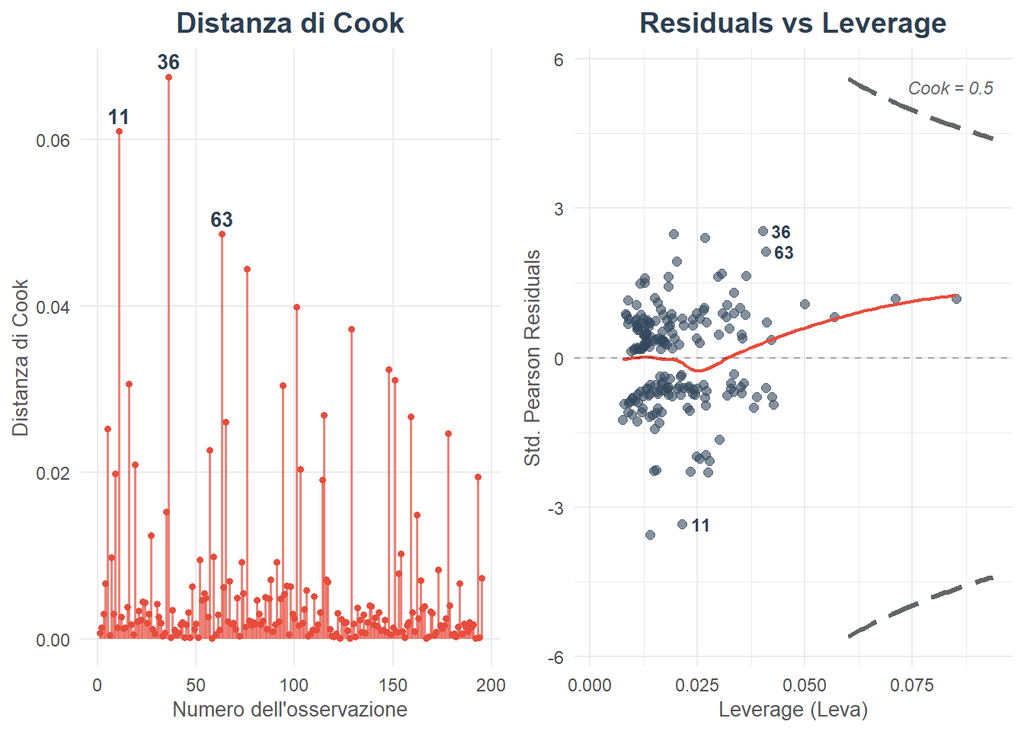

1. **Analisi dell’influenza (distanza di Cook):** il grafico a sinistra evidenzia che nessuna singola partita esercita un’influenza critica sui coefficienti. Il valore massimo (obs. 36) si attesta intorno a **0.0676**, un ordine di grandezza inferiore alla soglia di allerta convenzionale ($D > 0.5$ o $D > 1$). Ciò garantisce che il modello non sia eccessivamente influenzato da pochi casi isolati.
2. **Relazione Residui-Leva:** il grafico a destra evidenzia che i residui più marcati si concentrano prevalentemente nella zona a **leva medio-bassa**, indicando che gli errori di predizione riguardano match statisticamente standard. La linea di tendenza mostra una lieve deviazione positiva in corrispondenza dei valori di leva più alti: questo segnala una marginale imprecisione nelle stime di probabilità per i casi estremi, che tuttavia non inficia la capacità di classificazione globale del modello, come confermato dall’assenza di osservazioni nell’area critica di Cook.

## 7 **Analisi di performance**

### 7.1 *Curva ROC e AUC*

La prima fase della validazione misura la capacità del modello di discriminare tra vittorie e sconfitte sui dati inediti del *Test Set*. L’efficacia complessiva è quantificata dall’*Area Sotto la Curva* (**AUC**), dove 0.5 indica un modello casuale mentre 1 rappresenta un classificatore perfetto.

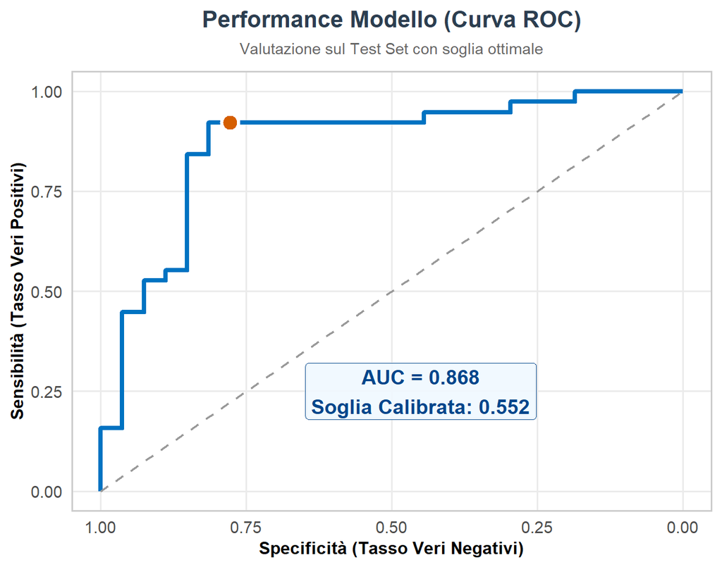

Il modello ottiene un AUC di **0.868**, valore che denota un’eccellente capacità predittiva. La curva si estende decisamente verso l’angolo superiore sinistro, confermando che il set di variabili selezionato è in grado di distinguere vittorie e sconfitte con un alto tasso di veri positivi mantenendo bassi i falsi positivi.

### 7.2 *Matrice di confusione e altre metriche*

Per tradurre le probabilità continue stimate dal modello in previsioni binarie (vittoria/sconfitta) è indispensabile stabilire una **soglia di taglio** (*cut-off*).

Anziché adottare a priori il valore standard di 0.5 (che presuppone costi di errore simmetrici e classi perfettamente bilanciate), si utilizza la **Soglia di Youden** calibrata nel paragrafo precedente. Questo indice *J* è definito come: $J = \text{Sensitivity} + \text{Specificity} - 1$. La selezione di tale soglia permette di identificare il punto operativo che massimizza congiuntamente la capacità del modello di rilevare i veri positivi e i veri negativi, adattando il decisore alla specifica distribuzione di probabilità dei dati. Per evitare fenomeni di *data leakage* (falsificazione dei risultati), la soglia è stata calcolata esclusivamente sul **Training Set** e viene qui applicata ai dati del **Test Set** per valutarne le performance reali.

Di seguito si riportano la Matrice di Confusione e le metriche di performance risultanti.

Confusion Matrix

|  | DATO | REALE |
| --- | --- | --- |
| PREVISIONE | SCONFITTA | VITTORIA |
| SCONFITTA | 21 | 3 |
| VITTORIA | 6 | 35 |

Metriche di valutazione

| Metrica | Valore | Descrizione |
| --- | --- | --- |
| Accuracy | 86.2% | Percentuale totale di risposte corrette. Il modello ha un’ottima capacità predittiva globale. |
| Sensitivity | 92.1% | Capacità di individuare le vittorie. Il modello riconosce quasi tutte le vere vittorie. |
| Specificity | 77.8% | Capacità di individuare le sconfitte. Il modello fatica un po’ di più a riconoscere quando un team perderà. |
| Precision | 85.4% | Affidabilità della previsione positiva. Quando il modello prevede ‘Vittoria’, ha ragione circa l’85.4% delle volte. |

## 8 **Conclusioni**

Lo studio si proponeva di quantificare il peso relativo del talento individuale (“*Carry*”) rispetto alla coesione del collettivo nel determinare la vittoria in *Valorant*. Come evidenziato dalla tabella degli *Odds Ratio*, la risposta statistica indica una chiara **predominanza del talento individuale**. La variabile `Rating_Max` si conferma il predittore più forte e significativo, suggerendo che la presenza di una “punta di diamante” è la condizione necessaria per spezzare gli equilibri della partita. Tuttavia, l’analisi rivela che la dimensione **collettiva** mantiene una rilevanza fondamentale, seppur in una forma diversa dalle metriche di supporto classiche (come il numero di *assist*, immediatamente scartato). La significatività della variabile `Rating_SD` dimostra che il successo del singolo dipende strettamente dalla solidità dei compagni: un team troppo sbilanciato annulla il vantaggio creato dal fuoriclasse. A completamento del quadro, emerge una sfumatura tattica legata alla disciplina. È significativo che il modello abbia selezionato le *First Deaths* scartando le speculari *First Kills*: mentre la capacità di aprire il round è statisticamente assorbita dal talento del fuoriclasse, la tendenza a subire la prima eliminazione rappresenta una dimensione distinta di **errore tattico**. Ciò suggerisce che, una volta garantita la potenza di fuoco, la vittoria si consolida minimizzando i vantaggi numerici concessi all’avversario.

In conclusione, la vittoria non è frutto del solo individualismo né del solo collettivismo, ma di una sinergia specifica: il **talento del singolo** genera le opportunità di vittoria, ma è l’**equilibrio della squadra**, unitamente alla disciplina tattica, a garantire che queste si concretizzino.

## 9 **Bibliografia**

Canty, A., & Ripley, B. (2025). *boot: Bootstrap Functions* (R package version 1.3-32). https://doi.org/10.32614/CRAN.package.boot

Fox, J., & Weisberg, S. (2019). *An R companion to applied regression* (3rd ed.). Sage. https://www.john-fox.ca/Companion/

Friedman, J., Hastie, T., & Tibshirani, R. (2010). Regularization paths for generalized linear models via coordinate descent. *Journal of Statistical Software*, 33(1), 1–22. https://doi.org/10.18637/jss.v033.i01

Kuhn, M. (2008). Building predictive models in R using the caret package. *Journal of Statistical Software*, 28(5), 1–26. https://doi.org/10.18637/jss.v028.i05

Luong, R. (2025). *Valorant Champion Tour 2021-2025 data* [Data set]. Kaggle. https://www.kaggle.com/datasets/ryanluong1/valorant-champion-tour-2021-2023-data (data di ultima consulta: 6 gennaio 2026)

R Core Team. (2025). *R: A language and environment for statistical computing*. R Foundation for Statistical Computing, Vienna, Austria. https://www.R-project.org/

Robin, X., Turck, N., Hainard, A., Tiberti, N., Lisacek, F., Sanchez, J. C., & Müller, M. (2011). pROC: an open-source package for R and S+ to analyze and compare ROC curves. *BMC Bioinformatics*, 12, 77. https://doi.org/10.1186/1471-2105-12-77

Robinson, D., Hayes, A., Couch, S., & Hvitfeldt, E. (2025). *broom: Convert statistical objects into tidy tibbles* (R package version 1.0.11). https://doi.org/10.32614/CRAN.package.broom

Walpole, R. E., Myers, R. H., Myers, S. L., & Ye, K. E. (2016). *Probabilità e statistica per ingegneria e scienze: Strumenti e applicazioni in R* (9a ed.). Pearson.

Wickham, H., Averick, M., Bryan, J., Chang, W., McGowan, L. D., François, R., Grolemund, G., Hayes, A., Henry, L., Hester, J., Kuhn, M., Pedersen, T. L., Miller, E., Bache, S. M., Müller, K., Ooms, J., Robinson, D., Seidel, D. P., Spinu, V., … Yutani, H. (2019). Welcome to the tidyverse. *Journal of Open Source Software*, 4(43), 1686. https://doi.org/10.21105/joss.01686

Youden, W. J. (1950). Index for rating diagnostic tests. *Cancer*, 3(1), 32–35. https://doi.org/bjw536